Problem 1

```r
rm(list = ls(all = T))
#1
library(alr4)
wb_means = c()
wb_sd = c()
for(i in 1 : 8){
  all_length = wblake$Length
  subgroup = all_length[wblake == i]
  wb_means[i] = mean(subgroup)
  wb_sd[i] = sd(subgroup)
}
ages = c(1 : 8)
```

```r
#(a)
wb_means
```

```
## [1]  98.34211 124.84722 152.56383 193.80000 221.72059 252.59770 269.86885
## [8] 306.25000
```

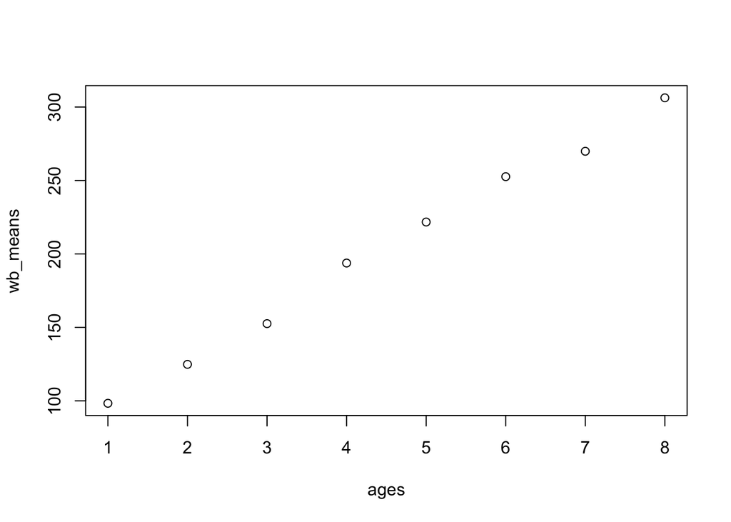

```r
plot(ages, wb_means)
```

From the plot, because we can see that the 8 points are approximately on a stright line, then I would say there is a evidence for a linear relationship between mean Length and Age.

```r
#(b)
wb_sd
```

```
## [1] 28.42941 26.40618 20.28960 29.45263 31.39581 33.24275 29.48529 42.46077
```

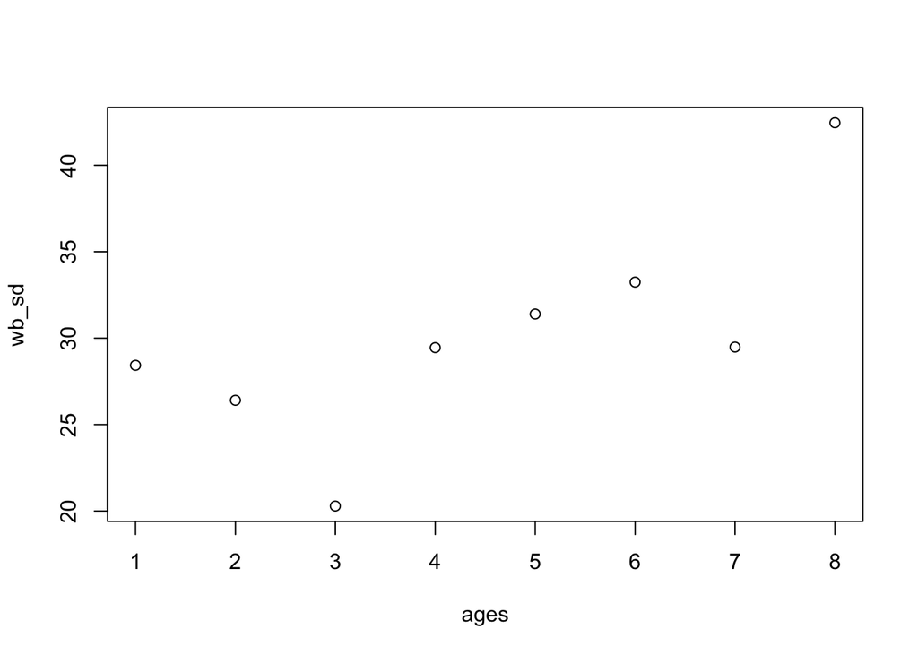

```r
plot(ages, wb_sd)
```

From the plot, because we can see that 8 points are not on a horizontal line, then I would say the variance does not appear constant across the different age population.

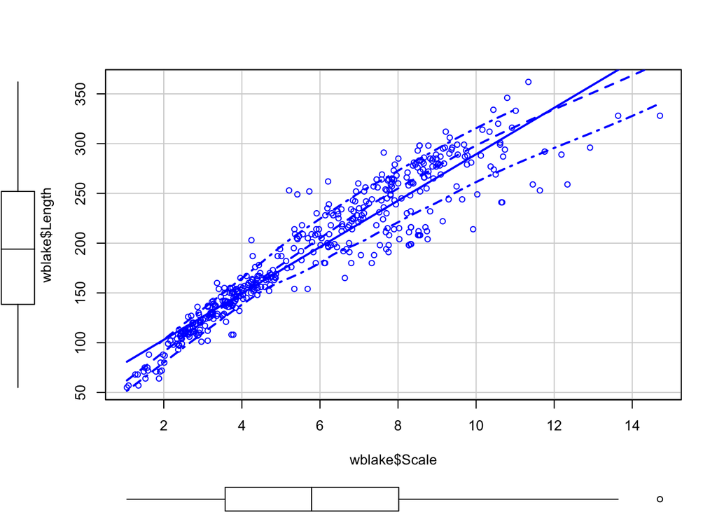

```r
#(c)
scatterplot(wblake$Scale, wblake$Length)
```

```r
lm.1 = lm(wblake$Length ~ wblake$Scale)
summary(lm.1)
```

```
##
## Call:
## lm(formula = wblake$Length ~ wblake$Scale)
##
## Residuals:
##     Min      1Q  Median      3Q     Max
## -84.896  -9.643  -0.021  14.651  75.290
##
## Coefficients:
##              Estimate Std. Error t value Pr(>|t|)
## (Intercept)   56.2986     2.6423   21.31   <2e-16 ***
## wblake$Scale  23.3068     0.4096   56.90   <2e-16 ***
## ---
## Signif. codes:  0 '***' 0.001 '**' 0.01 '*' 0.05 '.' 0.1 ' ' 1
##
## Residual standard error: 23.06 on 437 degrees of freedom
## Multiple R-squared:  0.8811, Adjusted R-squared:  0.8808
## F-statistic:  3237 on 1 and 437 DF,  p-value: < 2.2e-16
```

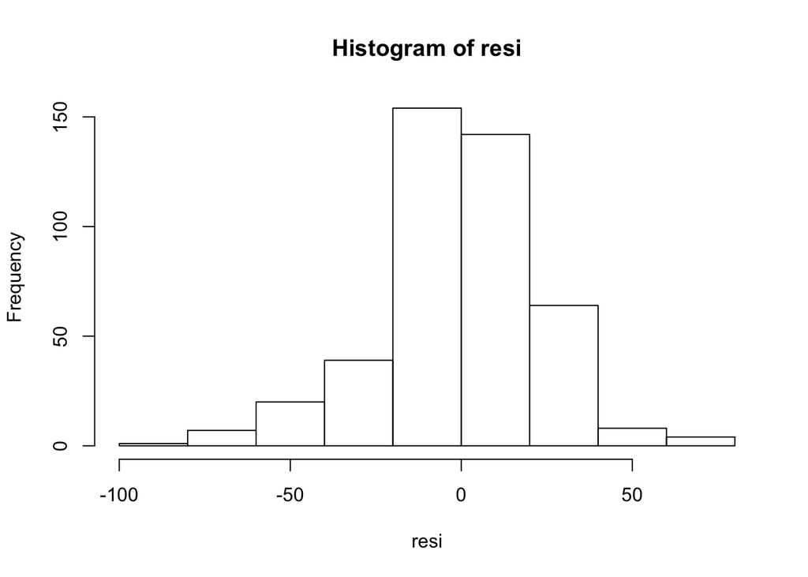

```r
#(d)
resi = lm.1$residuals
hist(resi)
```

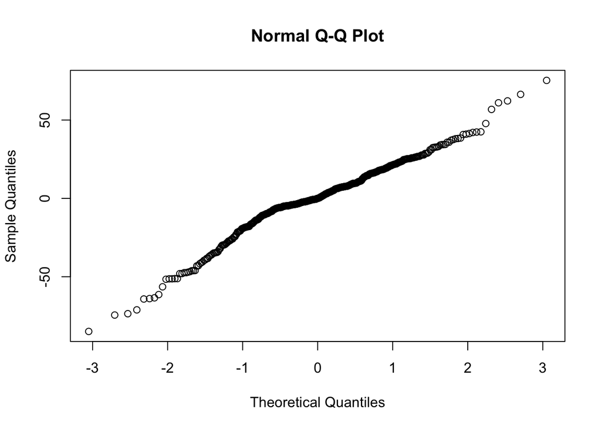

```r
qqnorm(resi)
```

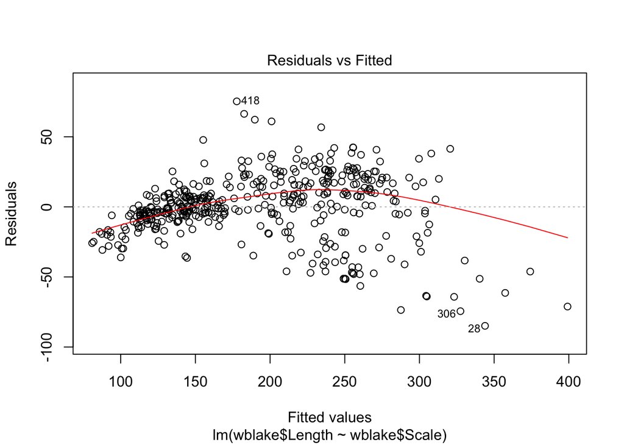

```r
plot(lm.1, which = 1)
```

Based on the shape of the histogram and the normal qqplot, the normality assumption is not violated. However, from the TA plot, the constant variance assumption appears not to hold. Therefore, this linear model doesn’t seem appropriate.

```r
#(e)
new = data.frame(Scale = 200)
fit = lm(Length~Scale, data = wblake)
#prediction
predict(fit, new, se.fit = T)$fit
```

```
##        1
## 4717.665
```

```r
#95% CI
(pre_CI = predict(fit, new, interval = "confidence", level = 0.95))
```

```
##        fit      lwr      upr
## 1 4717.665 4561.348 4873.983
```

```r
#90% PI
(pre_PI = predict(fit, new, interval = "prediction", level = 0.9))
```

```
##        fit      lwr      upr
## 1 4717.665 4581.166 4854.165
```

Problem 2 (a) predictor: PPgdp response: Fertility

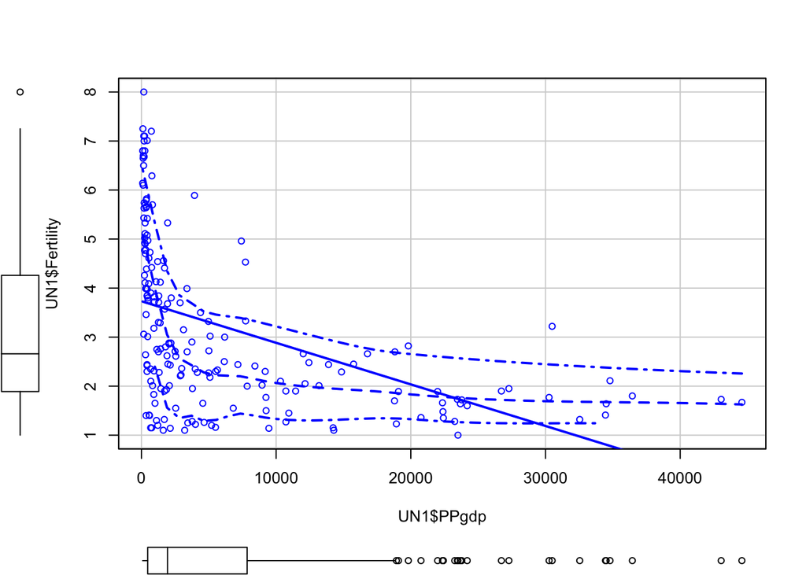

```r
rm(list = ls(all = T))
library(alr4)
#(b)
scatterplot(UN1$PPgdp, UN1$Fertility)
```

```r
summary(UN1$PPgdp)
```

```
##    Min. 1st Qu.  Median    Mean 3rd Qu.    Max.
##      90     467    1938    6408    7850   44579
```

```r
summary(UN1$Fertility)
```

```
##    Min. 1st Qu.  Median    Mean 3rd Qu.    Max.
##   1.000   1.890   2.660   3.189   4.260   8.000
```

Based on the shape of the graph, the linear model doesn’t seem fit here.

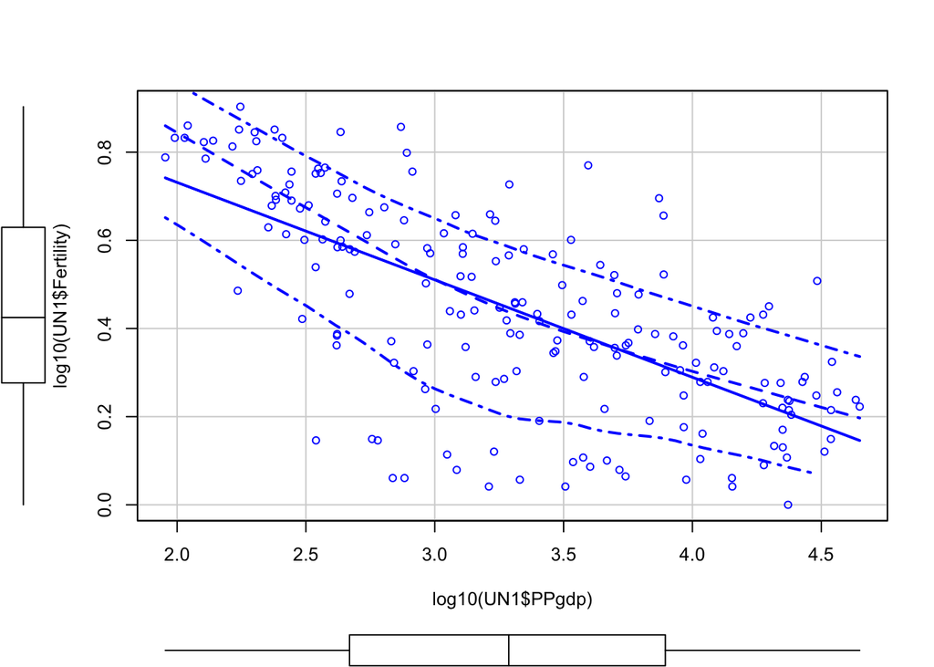

```r
#(c)
scatterplot(log10(UN1$PPgdp), log10(UN1$Fertility))
```

```r
#(d)
lm.1 = lm(log10(UN1$Fertility) ~ log10(UN1$PPgdp))
summary(lm.1)
```

```
##
## Call:
## lm(formula = log10(UN1$Fertility) ~ log10(UN1$PPgdp))
##
## Residuals:
##      Min       1Q   Median       3Q      Max
## -0.48587 -0.08148  0.03058  0.11327  0.39130
##
## Coefficients:
##                  Estimate Std. Error t value Pr(>|t|)
## (Intercept)       1.17399    0.05879   19.97   <2e-16 ***
## log10(UN1$PPgdp) -0.22116    0.01737  -12.73   <2e-16 ***
## ---
## Signif. codes:  0 '***' 0.001 '**' 0.01 '*' 0.05 '.' 0.1 ' ' 1
##
## Residual standard error: 0.1721 on 191 degrees of freedom
## Multiple R-squared:  0.4591, Adjusted R-squared:  0.4563
## F-statistic: 162.1 on 1 and 191 DF,  p-value: < 2.2e-16
```

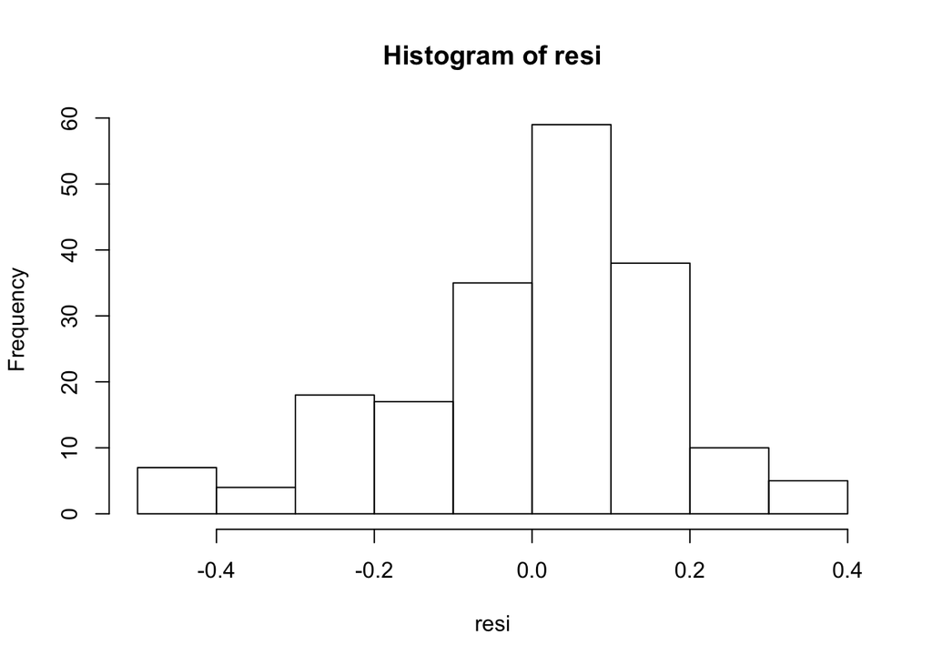

```r
#(e)
resi = lm.1$residuals
hist(resi)
```

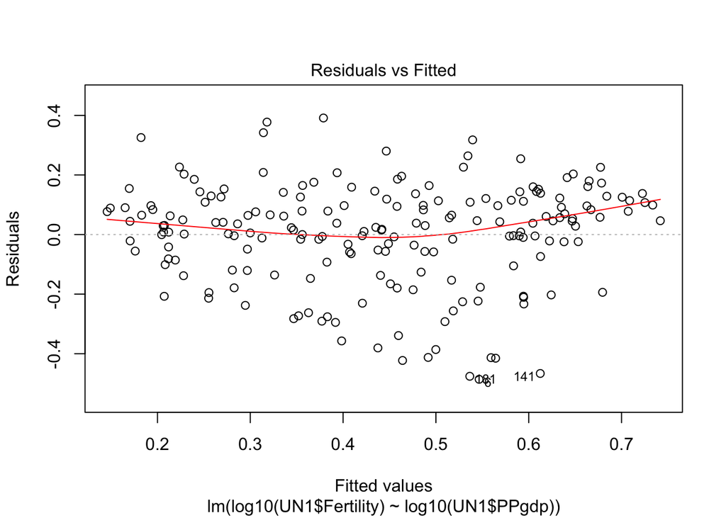

```r
plot(lm.1, which = 1)
```

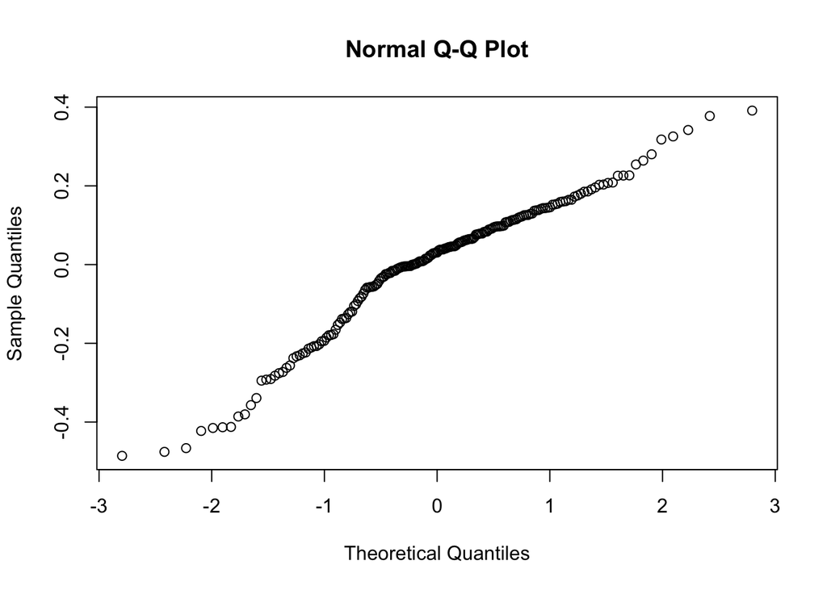

```r
qqnorm(resi)
```

Based on the shape of the histogram and the normal qqplot, the normality assumption is not violated. From the TA plot, the constant variance assumption seems also not violated.

```r
#(f)
summary(lm.1)
```

```
##
## Call:
## lm(formula = log10(UN1$Fertility) ~ log10(UN1$PPgdp))
##
## Residuals:
##      Min       1Q   Median       3Q      Max
## -0.48587 -0.08148  0.03058  0.11327  0.39130
##
## Coefficients:
##                  Estimate Std. Error t value Pr(>|t|)
## (Intercept)       1.17399    0.05879   19.97   <2e-16 ***
## log10(UN1$PPgdp) -0.22116    0.01737  -12.73   <2e-16 ***
## ---
## Signif. codes:  0 '***' 0.001 '**' 0.01 '*' 0.05 '.' 0.1 ' ' 1
##
## Residual standard error: 0.1721 on 191 degrees of freedom
## Multiple R-squared:  0.4591, Adjusted R-squared:  0.4563
## F-statistic: 162.1 on 1 and 191 DF,  p-value: < 2.2e-16
```

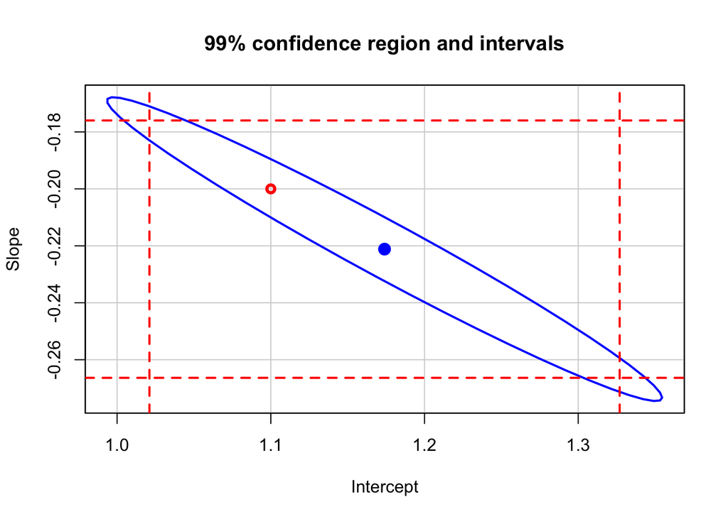

```r
#(g)
confidenceEllipse(lm.1, grid=TRUE, xlab="Intercept", ylab="Slope",
                        main="99% confidence region and intervals", levels = 0.99)
abline(h=confint(lm.1,level=.99)[2,1],lty=2,lwd=2,col="red")
abline(h=confint(lm.1,level=.99)[2,2],lty=2,lwd=2,col="red")
abline(v=confint(lm.1,level=.99)[1,1],lty=2,lwd=2,col="red")
abline(v=confint(lm.1,level=.99)[1,2],lty=2,lwd=2,col="red")
points(1.1, -.2,col="red",lwd=3)
```

Because the point (1.1, -0.2) is in the 1% confidence ellipse, I would not rejectt he hypothesis (β0, β1)T = (1.1, −.2) at the 1% level.